# Part I - Prosper Loan Data

## Introduction

Prosper is a peer-to-peer lending platform that lets borrowers access personal loans. Borrower qualifications are more accessible than many other online lenders, but rates can reach almost 36% and borrowers pay origination fees from 2.41% to 5%. Prospective borrowers can take advantage of Prosper’s prequalification tool to see what terms they’ll qualify for without impacting their credit scores.

The data set contains 113,937 loans with 81 variables on each loan, including loan amount, borrower rate (or interest rate), current loan status, borrower income, and many others

## Preliminary Wrangling

```python
# importing all packages and setting plots to be embedded inline
import numpy as np
import pandas as pd
import matplotlib.pyplot as plt
import seaborn as sb
import warnings

warnings.filterwarnings('ignore')

%matplotlib inline
```

> Loading the dataset and describring its properties.

```python
# Loading csv file into a dataframe
df = pd.read_csv('prosperLoanData.csv')
```

```python
# Describring dataframe properties
df.shape
```

```
(113937, 81)
```

```python
# Describring dataframe properties
df.info()
```

```
<class 'pandas.core.frame.DataFrame'>
RangeIndex: 113937 entries, 0 to 113936
Data columns (total 81 columns):
 #   Column                               Non-Null Count   Dtype
---  ------                               --------------   -----
 0   ListingKey                           113937 non-null  object
 1   ListingNumber                        113937 non-null  int64
 2   ListingCreationDate                  113937 non-null  object
 3   CreditGrade                          28953 non-null   object
 4   Term                                 113937 non-null  int64
 5   LoanStatus                           113937 non-null  object
 6   ClosedDate                           55089 non-null   object
 7   BorrowerAPR                          113912 non-null  float64
 8   BorrowerRate                         113937 non-null  float64
 9   LenderYield                          113937 non-null  float64
```

[output cut: 73 more lines]

```python
# Selecting variables of interest
df_prosper_loan = df[['LoanOriginalAmount','LoanStatus','BorrowerAPR','BorrowerRate','StatedMonthlyIncome', 'ProsperRating (Alpha)',
        'Term','EmploymentStatus','MonthlyLoanPayment','BorrowerState','DebtToIncomeRatio','ListingCategory (numeric)','ProsperScore']]
df_prosper_loan.info()
```

```
<class 'pandas.core.frame.DataFrame'>
RangeIndex: 113937 entries, 0 to 113936
Data columns (total 13 columns):
 #   Column                     Non-Null Count   Dtype
---  ------                     --------------   -----
 0   LoanOriginalAmount         113937 non-null  int64
 1   LoanStatus                 113937 non-null  object
 2   BorrowerAPR                113912 non-null  float64
 3   BorrowerRate               113937 non-null  float64
 4   StatedMonthlyIncome        113937 non-null  float64
 5   ProsperRating (Alpha)      84853 non-null   object
 6   Term                       113937 non-null  int64
 7   EmploymentStatus           111682 non-null  object
 8   MonthlyLoanPayment         113937 non-null  float64
 9   BorrowerState              108422 non-null  object
 10  DebtToIncomeRatio          105383 non-null  float64
 11  ListingCategory (numeric)  113937 non-null  int64
 12  ProsperScore               84853 non-null   float64
dtypes: float64(6), int64(3), object(4)
memory usage: 11.3+ MB
```

```python
# drop duplicates in the dataset
df_prosper_loan = df_prosper_loan.drop_duplicates()
```

```python
# Getting the number of missing values in each column
missing_values = df_prosper_loan.isna().sum()

# Excluding columns that contains 0 missing values
missing_values = missing_values[missing_values >= 1]

# Getting the percentages of missing values and round down the result
percent_missing = missing_values * 100 / df_prosper_loan.shape[0]
percent_missing = percent_missing.round(2)

# Concatenating the number and perecentage of missing values
# into one dataframe and sorting it
pd.concat([missing_values, percent_missing], axis=1,
          keys=['missing_values', 'Percentage']).\
          sort_values(by="missing_values", ascending=False)
```

|  | missing_values | Percentage |
| --- | --- | --- |
| ProsperRating (Alpha) | 29080 | 25.53 |
| ProsperScore | 29080 | 25.53 |
| DebtToIncomeRatio | 8545 | 7.50 |
| BorrowerState | 5515 | 4.84 |
| EmploymentStatus | 2255 | 1.98 |
| BorrowerAPR | 25 | 0.02 |

### selecting rows only where ProsperRating is not null as this is one of the most important features of the dataset

```python
# Discarding null values in ProsperRating (Alpha) column
df_prosper_loan = df_prosper_loan[df_prosper_loan['ProsperRating (Alpha)'].notnull()]
```

```python
# Filling in missing values of DebtToIncomeRatio column with its mean
df_prosper_loan.DebtToIncomeRatio = df_prosper_loan.DebtToIncomeRatio.fillna(df_prosper_loan.DebtToIncomeRatio.mean())
```

```python
# Checking changes made
df_prosper_loan.info()
```

```
<class 'pandas.core.frame.DataFrame'>
Int64Index: 84838 entries, 1 to 113936
Data columns (total 13 columns):
 #   Column                     Non-Null Count  Dtype
---  ------                     --------------  -----
 0   LoanOriginalAmount         84838 non-null  int64
 1   LoanStatus                 84838 non-null  object
 2   BorrowerAPR                84838 non-null  float64
 3   BorrowerRate               84838 non-null  float64
 4   StatedMonthlyIncome        84838 non-null  float64
 5   ProsperRating (Alpha)      84838 non-null  object
 6   Term                       84838 non-null  int64
 7   EmploymentStatus           84838 non-null  object
 8   MonthlyLoanPayment         84838 non-null  float64
 9   BorrowerState              84838 non-null  object
 10  DebtToIncomeRatio          84838 non-null  float64
 11  ListingCategory (numeric)  84838 non-null  int64
 12  ProsperScore               84838 non-null  float64
dtypes: float64(6), int64(3), object(4)
memory usage: 9.1+ MB
```

```python
# Describing the statistics for numeric variables
df_prosper_loan.describe()
```

|  | LoanOriginalAmount | BorrowerAPR | BorrowerRate | StatedMonthlyIncome | Term | MonthlyLoanPayment | DebtToIncomeRatio | ListingCategory (numeric) | ProsperScore |
| --- | --- | --- | --- | --- | --- | --- | --- | --- | --- |
| count | 84838.000000 | 84838.000000 | 84838.000000 | 8.483800e+04 | 84838.000000 | 84838.000000 | 84838.000000 | 84838.000000 | 84838.000000 |
| mean | 9083.808883 | 0.226659 | 0.196022 | 5.931308e+03 | 42.486433 | 291.941962 | 0.258753 | 3.312926 | 5.949999 |
| std | 6287.895615 | 0.079909 | 0.074625 | 8.240481e+03 | 11.640653 | 186.679553 | 0.304354 | 4.364563 | 2.376429 |
| min | 1000.000000 | 0.045830 | 0.040000 | 0.000000e+00 | 12.000000 | 0.000000 | 0.000000 | 0.000000 | 1.000000 |
| 25% | 4000.000000 | 0.163280 | 0.135900 | 3.434042e+03 | 36.000000 | 157.330000 | 0.160000 | 1.000000 | 4.000000 |
| 50% | 7500.000000 | 0.219450 | 0.187500 | 5.000000e+03 | 36.000000 | 251.940000 | 0.240000 | 1.000000 | 6.000000 |
| 75% | 13500.000000 | 0.292540 | 0.257400 | 7.083333e+03 | 60.000000 | 388.350000 | 0.310000 | 3.000000 | 8.000000 |
| max | 35000.000000 | 0.423950 | 0.360000 | 1.750003e+06 | 60.000000 | 2251.510000 | 10.010000 | 20.000000 | 11.000000 |

### What is/are the main feature(s) of interest in your dataset?

> ProsperRating (Alpha) is the variable of interest because it is what potential investors use to decide whether to invest in the loan listing.

### What features in the dataset do you think will help support your investigation into your feature(s) of interest?

> Prosper rate is the key for the envestigation, the prosper rate will be compared to income and employement status.

```python
#Ordering Prosper Rating
ordinal_var_dict = {'ProsperRating (Alpha)': ['AA','A','B','C','D','E','HR']}

for var in ordinal_var_dict:
    ordered_var = pd.api.types.CategoricalDtype(ordered = True,
                                                categories = ordinal_var_dict[var])
    df_prosper_loan[var] = df_prosper_loan[var].astype(ordered_var)
```

```python
# Assigning new ordered Prosper Rating to dataframe
df_prosper_loan['ProsperRating (Alpha)'] = df_prosper_loan['ProsperRating (Alpha)']
```

## Univariate Exploration

```python
# creating a function for vertical catplots
def gt(df_prosper_loan,xvar):
    g=sb.catplot(data=df_prosper_loan, x=xvar,color = 'blue', kind='count',
           height=8 , alpha=.5, order=df_prosper_loan[xvar].value_counts().index)

    g.despine(left=True)
    xvar=xvar.replace("_","")

    g.set_axis_labels(f"Distribution of {xvar}",xvar.title())
    plt.title(f'distribution of {xvar}'.title(),weight="bold")
```

```python
# creating a function for holizontal catplots
def gth(df_prosper_loan,yvar):
    g=sb.catplot(data=df_prosper_loan, y=yvar,color = 'blue', kind='count',
           height=10 , alpha=.6, order=df_prosper_loan[yvar].value_counts().index)

    g.despine(left=True)
    yvar=yvar.replace("_","")

    g.set_axis_labels(f"Count of {yvar}",yvar)
    plt.title(f'distribution of {yvar}'.title(),weight="bold")
```

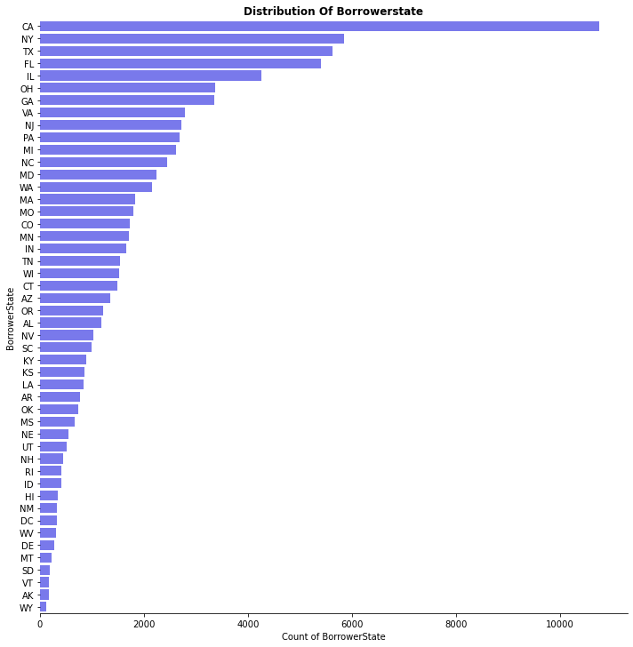

```python
#Plotting distrubtion of borrowers statewise
gth(df_prosper_loan,yvar='BorrowerState')
```

The visualization above shows that most borrowers on Prosper come from California state.

```python
# Adding Full-time to employed as in most cases they are the same
df_prosper_loan['EmploymentStatus'] = df_prosper_loan['EmploymentStatus'].replace(['Employed'],'Full-time')
```

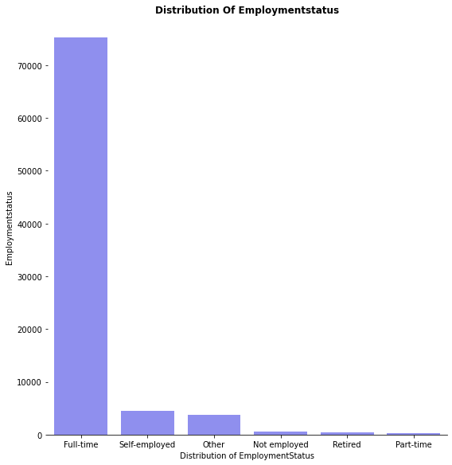

```python
#Plotting distrubtion of borrowers Employment Status
gt(df_prosper_loan,'EmploymentStatus')
```

As we can see from above figure, most people who request for loan are full-time employees.

```python
# Applying Amprical rule 3 sd cover 99.7% of the data
income_std = df_prosper_loan['StatedMonthlyIncome'].std()
income_mean = df_prosper_loan['StatedMonthlyIncome'].mean()
boundary = income_std + income_mean * 3
```

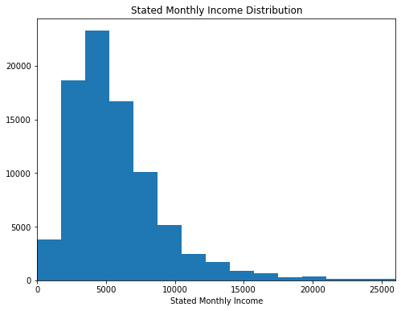

```python
# Plotting zoomed in graph
plt.figure(figsize=[ 8, 6])
plt.hist(data=df_prosper_loan, x='StatedMonthlyIncome', bins=1000);
plt.xlim(0, boundary);
plt.title('Stated Monthly Income Distribution')
plt.xlabel('Stated Monthly Income');
```

We can see from the right skewed graph that many borrowes earn around 5,000 per month.

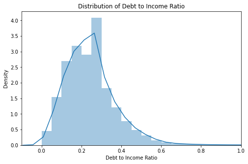

```python
# Debt To Income distribution
plt.figure(figsize = [8,5])
sb.distplot(df_prosper_loan.DebtToIncomeRatio, kde = True ,bins = 200)
plt.xlim(-.1, 1)
plt.xlabel('Debt to Income Ratio')
plt.title('Distribution of Debt to Income Ratio');
```

Above distribution plot shows that most borrowers who apply for a loan have a debt to income ratio around 20%.

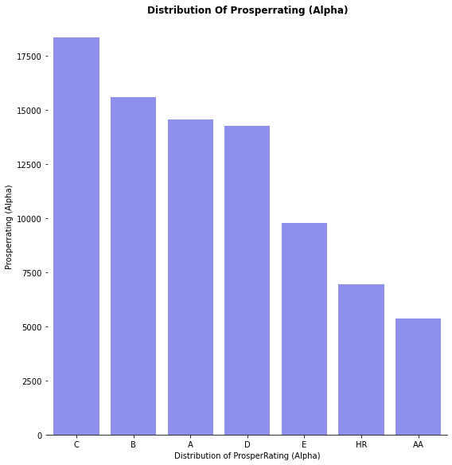

```python
#Plotting distrubtion of borrowers Prosper Rating
gt(df_prosper_loan,'ProsperRating (Alpha)')
```

Above graph displays the majority of borrowers have (C) prosper rating which is estimated average annual loss rate between 6% and 9% rating.

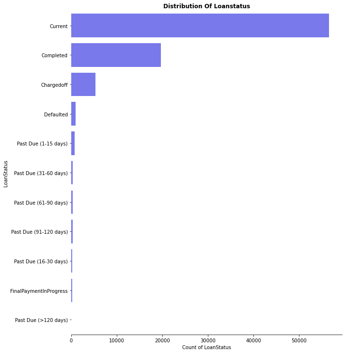

```python
#Plotting distrubtion of borrowers
gth(df_prosper_loan,'LoanStatus')
```

More than 50 thousands loans are still not payed off.

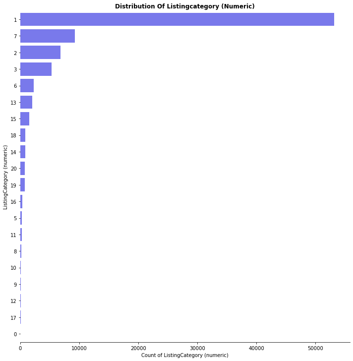

```python
#Plotting distribution of Listing Category
gth(df_prosper_loan,'ListingCategory (numeric)')
```

The category of the listing that the borrower selected when posting their listing: 0 - Not Available, 1 - Debt Consolidation, 2 - Home Improvement, 3 - Business, 4 - Personal Loan, 5 - Student Use, 6 - Auto, 7- Other, 8 - Baby&Adoption, 9 - Boat, 10 - Cosmetic Procedure, 11 - Engagement Ring, 12 - Green Loans, 13 - Household Expenses, 14 - Large Purchases, 15 - Medical/Dental, 16 - Motorcycle, 17 - RV, 18 - Taxes, 19 - Vacation, 20 - Wedding Loans.

The majority of borrower choose **Debt Consolidation**.

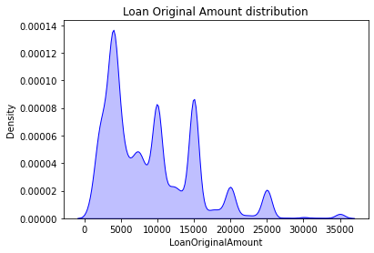

```python
# Plotting Loan Original Amount
sb.kdeplot(df_prosper_loan['LoanOriginalAmount'], shade=True, color="blue")
plt.title('Loan Original Amount distribution');
```

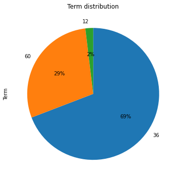

```python
#Plotting distrubtion of borrowers Term
df_prosper_loan.Term.value_counts().plot(kind = 'pie', figsize = (8,6), startangle = 90, counterclock = False, autopct='%.0f%%');
plt.title("Term distribution");
```

As we can see from above pie cher, 69% of borrowers took the loan of 36 months or which is equivalent to 3 Years.